# Part 2: Differential Expression Analysis

UFHCI BCB-SR Bioinformatics Unit

2026-04-09

## Overview

In this notebook we test for differentially expressed genes between PRMT7 knockdown and wildtype samples using the limma-voom framework.

**Requires:** `DGE_filtered_normalized.rds` produced by `02_quality_control.Rmd`

## Setup

```r
library(limma)
library(edgeR)
library(tidyverse)
library(ggrepel)
library(pheatmap)
library(RColorBrewer)
library(here)

set.seed(42)

results_dir <- here("demo-analysis", "output", "differential-expression", "results")
figures_dir <- here("demo-analysis", "output", "differential-expression", "figures")

dir.create(results_dir, showWarnings = FALSE, recursive = TRUE)
dir.create(figures_dir, showWarnings = FALSE, recursive = TRUE)
```

## Load Data

Load the filtered and normalized DGEList object saved at the end of Part 1.

```r
DGE <- readRDS(here("demo-analysis", "output", "differential-expression",
                    "DGE_filtered_normalized.rds"))

cat("Genes:", nrow(DGE), "| Samples:", ncol(DGE), "\n")
```

```
## Genes: 13783 | Samples: 6
```

```r
cat("Groups:", paste(levels(DGE$samples$group), collapse = ", "), "\n")
```

```
## Groups: PRMT7_WT, PRMT7_KD
```

```r
DGE$samples
```

```
##                group lib.size norm.factors      sample genotype treatment
## SRR12546980 PRMT7_WT 24323440    0.9658872 SRR12546980 PRMT7_WT Untreated
## SRR12546982 PRMT7_KD 29211491    1.0310403 SRR12546982 PRMT7_KD Untreated
## SRR12546984 PRMT7_WT 25741290    0.9680670 SRR12546984 PRMT7_WT Untreated
## SRR12546986 PRMT7_KD 25511001    1.0323176 SRR12546986 PRMT7_KD Untreated
## SRR12546988 PRMT7_WT 25427173    0.9659094 SRR12546988 PRMT7_WT Untreated
## SRR12546990 PRMT7_KD 29730447    1.0402622 SRR12546990 PRMT7_KD Untreated
##                     Run
## SRR12546980 SRR12546980
## SRR12546982 SRR12546982
## SRR12546984 SRR12546984
## SRR12546986 SRR12546986
## SRR12546988 SRR12546988
## SRR12546990 SRR12546990
```

## Design Matrix

The design matrix tells limma which samples belong to which groups and what we want to test. The first factor level (`PRMT7_WT`) is the reference — fold changes are expressed relative to WT.

- **Intercept**: Average expression in PRMT7_WT
- **genotypePRMT7_KD**: The log2 fold-change between KD and WT — this is what we are testing

```r
# WT is the reference level (listed first)
DGE$samples$genotype <- factor(DGE$samples$genotype,
                                levels = c("PRMT7_WT", "PRMT7_KD"))

design <- model.matrix(~genotype, data = DGE$samples)
design
```

```
##             (Intercept) genotypePRMT7_KD
## SRR12546980           1                0
## SRR12546982           1                1
## SRR12546984           1                0
## SRR12546986           1                1
## SRR12546988           1                0
## SRR12546990           1                1
## attr(,"assign")
## [1] 0 1
## attr(,"contrasts")
## attr(,"contrasts")$genotype
## [1] "contr.treatment"
```

```r
colnames(design)
```

```
## [1] "(Intercept)"      "genotypePRMT7_KD"
```

## voom Transformation

voom converts counts to log2-CPM and calculates a precision weight for each observation based on the mean-variance relationship. The resulting plot should show a smooth downward-sloping red curve — highly expressed genes have more stable variance and receive higher weights in the model.

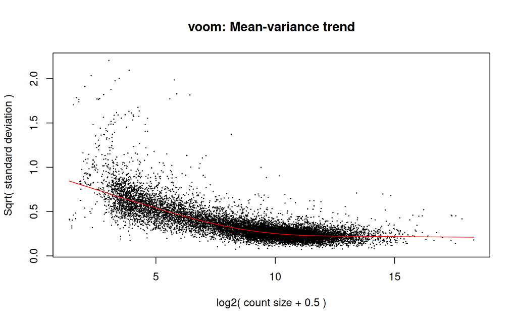

```r
# normalize.method = "none" because TMM was already applied in Part 1
v <- voom(DGE,
          design           = design,
          normalize.method = "none",
          plot             = TRUE)
```

## Fit Linear Model

`lmFit` fits a linear model to each gene. `eBayes` applies empirical Bayes moderation, which borrows information across genes to stabilize variance estimates — particularly important for small sample sizes.

```r
fit <- lmFit(v, design)
fit <- eBayes(fit, robust = TRUE)

# Summary of DE genes at FDR < 0.05
# Down = lower in KD, Up = higher in KD
summary(decideTests(fit, adjust.method = "fdr", p.value = 0.05, lfc = 1))
```

```
##        (Intercept) genotypePRMT7_KD
## Down           903              779
## NotSig        1660            11569
## Up           11220             1435
```

## Extract Results

`topTable` extracts the full results table. `coef = 2` refers to the `genotypePRMT7_KD` coefficient — the KD vs WT comparison.

```r
top_genes_strict <- topTable(fit,
                             coef = 2,
                             adjust.method = "BH",
                             number = 20,
                             sort.by = "P",
                             lfc = 1)
cat("\nTop 20 genes (FDR < 0.05, |logFC| > 1):\n")
```

```
##
## Top 20 genes (FDR < 0.05, |logFC| > 1):
```

```r
print(top_genes_strict)
```

[output not shown]

```r
cat("Total genes tested:    ", nrow(top_genes_strict), "\n")
```

```
## Total genes tested:     20
```

```r
cat("DE genes (FDR < 0.05):", sum(top_genes_strict$adj.P.Val < 0.05), "\n")
```

```
## DE genes (FDR < 0.05): 20
```

```r
cat("Up in KD:             ", sum(top_genes_strict$adj.P.Val < 0.05 & top_genes_strict$logFC > 0), "\n")
```

```
## Up in KD:              13
```

```r
cat("Down in KD:           ", sum(top_genes_strict$adj.P.Val < 0.05 & top_genes_strict$logFC < 0), "\n\n")
```

```
## Down in KD:            7
```

```r
# Top 20 by p-value
topTable(fit, coef = 2, adjust.method = "BH", number = 20, sort.by = "P", lfc = 1)
```

[output not shown]

## Volcano Plot

A volcano plot shows log-fold change (x-axis) against statistical significance (y-axis). Genes in the upper corners are both large in effect size and highly significant. Dashed lines mark a 2-fold change threshold and p = 0.05.

```r
# All results for visualization
all_results <- topTable(fit,
                        coef = 2,
                        adjust.method = "BH",
                        number = Inf,
                        sort.by = "none")

all_results$category <- case_when(
  all_results$adj.P.Val < 0.05 & all_results$logFC >  1 ~ "Up (>2-fold)",
  all_results$adj.P.Val < 0.05 & all_results$logFC < -1 ~ "Down (>2-fold)",
  all_results$adj.P.Val < 0.05                           ~ "Significant",
  TRUE                                                    ~ "Not Significant"
)

table(all_results$category)
```

```
##
##  Down (>2-fold) Not Significant     Significant    Up (>2-fold)
##             779            3593            7976            1435
```

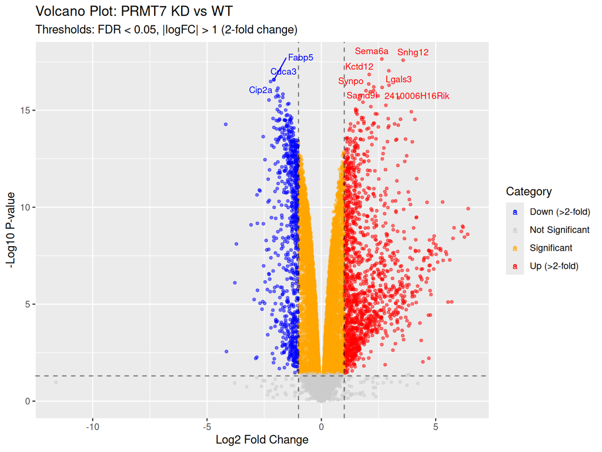

```r
all_results$label <- ifelse(
  rownames(all_results) %in% rownames(topTable(fit, coef = 2, number = 10, lfc = 1)),
  rownames(all_results),
  NA
)

ggplot(all_results, aes(x = logFC, y = -log10(P.Value), color = category)) +
  geom_point(alpha = 0.5, size = 1) +
  scale_color_manual(values = c("Up (>2-fold)" = "red",
                                "Down (>2-fold)" = "blue",
                                "Significant" = "orange",
                                "Not Significant" = "grey80")) +
  geom_vline(xintercept = c(-1, 1), linetype = "dashed", alpha = 0.5) +
  geom_hline(yintercept = -log10(0.05), linetype = "dashed", alpha = 0.5) +
  labs(title = "Volcano Plot: PRMT7 KD vs WT",
       subtitle = "Thresholds: FDR < 0.05, |logFC| > 1 (2-fold change)",
       x = "Log2 Fold Change",
       y = "-Log10 P-value",
       color = "Category") +
  geom_text_repel(aes(label = label), size = 3, max.overlaps = 20, na.rm = TRUE)
```

```r
  theme_minimal() +
  theme(legend.position = "right")
```

[output not shown]

[output cut: 313 more lines]

[output not shown]

```r
ggsave(here(figures_dir, "volcano_plot.png"), width = 8, height = 6, dpi = 300)
```

## MA Plot

An MA plot shows log-fold change (y-axis) against average expression (x-axis). The bulk of genes should sit around logFC = 0, with DE genes scattered above and below. A systematic trend would suggest a normalization problem.

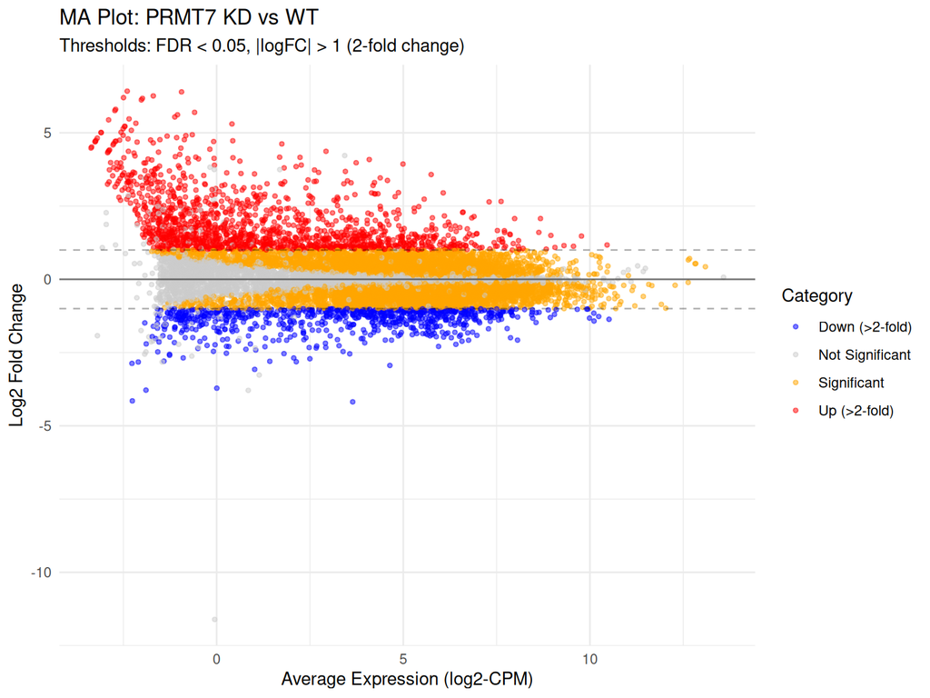

```r
ggplot(all_results, aes(x = AveExpr, y = logFC, color = category)) +
  geom_point(alpha = 0.5, size = 1) +
  scale_color_manual(values = c("Up (>2-fold)" = "red",
                                "Down (>2-fold)" = "blue",
                                "Significant" = "orange",
                                "Not Significant" = "grey80")) +
  geom_hline(yintercept = 0, linetype = "solid", alpha = 0.5) +
  geom_hline(yintercept = c(-1, 1), linetype = "dashed", alpha = 0.3) +
  labs(title = "MA Plot: PRMT7 KD vs WT",
       subtitle = "Thresholds: FDR < 0.05, |logFC| > 1 (2-fold change)",
       x = "Average Expression (log2-CPM)",
       y = "Log2 Fold Change",
       color = "Category") +
  theme_minimal()
```

```r
ggsave(here(figures_dir, "ma_plot.png"), width = 8, height = 6, dpi = 300)
```